# Homework 4: Computational Molecular Medicine

Sophia Doerr

April 25, 2017

# Statistical Analysis of Microarray Data Using SVA, k-TSP, and SVM

## Surrogate Variable Analysis (SVA)

As described in the assignment, there are many possible batch effects because the data was collected by three different European labs and data collected by microarray from the same phenotypes but by different labs can be widely varying. Surrogate variable analysis is one way to try and filter out these batch effects (and has been suggested by Dr. Bader) when we’re not sure where they came from. Leek et. al (2010) define batch effects as follows: Batch effects are sub-groups of measurements that have qualitatively different behaviour across conditions and are unrelated to the biological or scientific variables in a study. For example, batch effects may occur if a subset of experiments was run on Monday and another set on Tuesday, if two technicians were responsible for different subsets of the experiments, or if two different lots of reagents, chips or instruments were used. I will identify and estimate batch effects of this high thoroughput study using the R SVA package. “Removing batch effects and using surrogate variables in differential expression analysis have been shown to reduce dependence, stabilize error rate estimates, and improve reproducibility” (Leek et al).

As discussed in Leeks research (a top biostatician at Johns Hopkins University), this method is merely used at removing noise and batch effects on ALL of the data before even moving to training and testing. This is justified because this is not selecting predictive subsets using all the data, but merely a filtering technique. Anyone who would like to read more about this can reference Jeffrey Leek’s Thesis paper, “Surrogate Variable Analysis”, 2008.

Note: In order to be able to run this code, several different packages are needed. A few are from bioconductor, and will require the following code to install each of them:

source(“http://bioconductor.org/biocLite.R”)  
biocLite(“sva”)  
install.packages(‘ROCR’)  
install.packages(‘e1071’)  
source(“https://bioconductor.org/biocLite.R”)  
biocLite(“switchBox”)  
(after installed, use require(‘switchBox’))

```r
# The phenotype data has been organized in such a manner that needs preprocessing
# The data is not numerical, so below I will have code to convert it
library(readr)

cmm_path = "C:/Users/sophi/Documents/JHUDoerr/JHU 2016-17/Spring 2017/Computational Molecular Medicine/HW4/brcaDataSets3_HW4"
cat(file.path(cmm_path,"brcaTestPheno.csv"))
```

```
## C:/Users/sophi/Documents/JHUDoerr/JHU 2016-17/Spring 2017/Computational Molecular Medicine/HW4/brcaDataSets3_HW4/brcaTestPheno.csv
```

```r
brcaTestPheno <- read_csv(file.path(cmm_path,"brcaTestPheno.csv"))
brcaTestExpr <- read_csv(file.path(cmm_path,"brcaTestExpr.csv"))
brcaTrainPheno <- read_csv(file.path(cmm_path,"brcaTrainPheno.csv"))
brcaTrainExpr <- read_csv(file.path(cmm_path,"brcaTrainExpr.csv"))
nobs <- 212
# make new numerical vectors to store binary phenotype information
testPheno <- vector("numeric",nobs)
trainPheno <- vector("numeric",nobs)

for (i in seq(1,nobs)){
  if (brcaTestPheno[i,2] == 'Relapse') {
    testPheno[i] <- 1
  } else if (brcaTestPheno[i,2] == 'NoRelapse') {
    testPheno[i] <- 0
  }
  if (brcaTrainPheno[i,2] == 'Relapse'){
    trainPheno[i] <- 1
  } else if (brcaTrainPheno[i,2] == 'NoRelapse'){
    trainPheno[i] <- 0
  }
}
```

### SVA

```r
# The sva function takes the training data and calculates the number of surrogate variables
#Then inputting this information into the fsva function filters out batch effects for all
# of the data and outputs it in the form of a dataframe as an object of fsva
library(sva)
require('switchBox')
library(e1071)
library(ROCR)
trainData = as.matrix(brcaTrainExpr[,2:(nobs+1)])
testData = as.matrix(brcaTestExpr[,2:(nobs+1)])
trainMod = model.matrix(~trainPheno)
trainMod0 = model.matrix(~1,data=data.frame(trainPheno))
trainSv = sva(trainData,trainMod,trainMod0)
```

```
## Number of significant surrogate variables is:  26
## Iteration (out of 5 ):1  2  3  4  5
```

```r
fsvaobj = fsva(trainData,trainMod,trainSv,testData)
```

## Using k-TSP to find Differentially Expressed Genes

There are many different types of algorithms and classifiers in the world of machine learning and many techniques that can be applied to predict an outcome class in a testing set of data. After researching a few of the algorithms that have been used in cancer outcome prediction, I found an article, “Top Scoring pairs for feature selection in machine learning and applications to cancer outcome prediction” by Shi et al. The article discusses how k-TSP has been widely applied to microarray data sets such as the set that we are analyzing. However, they applied different techniques involving using k-TSP by itself, using Support Vector Machine, using k-TSP to select differentially expressed genes and then using SVM as a classifier, along wiht many other processes, and it was found that the combination of k-TSP and then SVM was the most effective in error rates for cancer outcome prediction. Based on this assertion, I will be applying this process to the data set we have been given and analyzing how well it performs based on several different factors. In the end I will compare this to simply using k-TSP.

The k-Top Scoring Pair Algorithm is a generalization off of Gemen’s Top Scoring Pair Algorithm introduced in 2004. The algorithm. Consider
$$G$$
genes with expression level
$$\textbf{X}={X_{1},X_{2},...,X_{G}}$$
for each sample (patient), and each has a class
$$C = 0,1$$
, which in this case we have two classes where 0 is no relapse and 1 is relapse. The top scoring pair algorithm finds the top most predictive pairs where the probability of the expression levels
$$X_{i} < X_{j}$$
in class 0 is much different than in class 1, where
$$j \ne i$$
. The conditional probability is then calculated based on the observed frequencies for each possible pair of genes in the set, or
$$p_{ij} = P(X_{i}< X_{j}| 0,1)$$
. A score is then calculated for each pair:
$$\delta_{ij} = |p_{ij} - p_{ji}|$$
, and then the pairs are ranked based on their score. The highest scoring k pairs are chosen for the k-TSP Algorithm. For this particular application I won’t explain how it can then be used as a classifier because I am using this for limiting the genes based on differential expression. 2- fold cross validation will be used.

```r
# Arrange data for k-TSP function, add rownames
x <- unlist(brcaTestExpr[,1]) # Take rownames from original dataset
f1_Expr <- fsvaobj$db
f2_Expr <- fsvaobj$new
f1_Pheno <- trainPheno
f2_Pheno <- testPheno
rownames(f1_Expr) <- x
rownames(f2_Expr) <- x

# Perform filtering with k-TSP separately on both folds

topx <- 50
# Fold 1
# This applies the k-TSP algorithm and finds top k pairs (50)
scores <- SWAP.CalculateScores(f1_Expr,factor(f1_Pheno))
pairs <- SWAP.MakeTSPTable(scores,topx*2,disjoint = TRUE)
f1_topxPairs <- pairs[1:topx,1:3]
f1_topxIndices <- vector('numeric',2*topx)
for (j in seq(1,topx)){
  f1_topxIndices[j] <- which(brcaTrainExpr[,1] == as.character(as.matrix(pairs[j,1])) , arr.ind = T)[1]
  f1_topxIndices[j+topx] <- which(brcaTrainExpr[,1] == as.character(as.matrix(pairs[j,2]), arr.ind = T))[1]
}

# Fold 2
# Applies k-TSP algorithm and finds top k pairs (50)
scores <- SWAP.CalculateScores(f2_Expr,factor(f2_Pheno))
pairs <- SWAP.MakeTSPTable(scores,topx*2,disjoint = TRUE)
f2_topxPairs <- pairs[1:topx,1:3]
f2_topxIndices <- vector('numeric',2*topx)
for (j in seq(1,topx)){
  f2_topxIndices[j] <- which(brcaTrainExpr[,1] == as.character(as.matrix(pairs[j,1])) , arr.ind = T)[1]
  f2_topxIndices[j+topx] <- which(brcaTrainExpr[,1] == as.character(as.matrix(pairs[j,2]), arr.ind = T))[1]
}
```

## Using Support Vector Machine for Classification

The F-measure is a measure of precision and recall at each different threshold level for a discriminant function. In this case, the discriminant function is the hyperplane which separates the two classes using SVM. The SVM algorithm finds the optimal hyperplane which leads to the best classification. In this example I am using a linear kernel, as is done in the paper I am replicating, not only because this is the procedure they used but also because upon trying different algorithms (radial, polynomial, etc.), the linear kernel performed the best. The decision rule in this case uses a vector w that must be perpendicular to the linear hyperplane, and that extends from the origin. if u is any vector or data point that we are testing ( a vector because each data point has a value for each of the genes), then the decision rule is:
$$\textbf{w} \bullet \textbf{u} +b \geq 0$$
where the data point is classified as one class when greater than or equal to 0 and another when less than 0, where b is a constant. By using Lagrange multipliers, the value for w is found and then for each data point this is calculated. This is the basis of the discriminant funciton for SVM, and is what is being calculated in the svm funciton in the e1071 package in R.

Precision is the ratio of the number of correctly predicted classes of label 1 over the total number of classes predicted to be in class 1. Recall is the fraction of total class labels that were actually 1 that were predicted to be 1. Sensitivity is actually the same as recall and specificity is the number of cases that were predicted class label 0 that were actually class label 0 over all the classes that were predicted to be 0’s. The F-measure is:
$$Fmeasure = 2* \frac{precision*recall}{precision + recall}$$
. This is also referred to as a harmonic mean. This is a measure that will be calculated and shown for each of the subset sizes (I will be testing different subset sizes to see which number of differentially expressed genes leads to the best results).

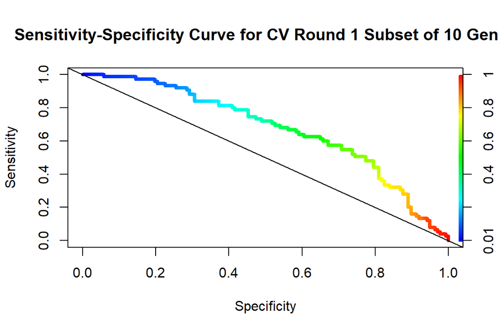

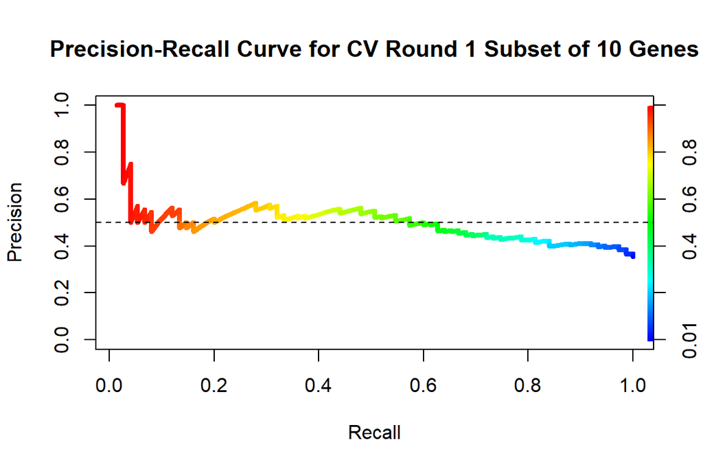

```
## Round 1 Cross Validation for using 10 differentially expressed genes
## Accuracy: 0.636792452830189
## Sensitivity-Specificity AUC: 0.672700729927007
## Smallest Sensitivity over .80: 0.802919708029197
## Corresponding Specifcity: 0.44
## Precision-Recall AUC: 0.672700729927007
## Maximum F-score: 0.570247933884298
## Maximum F-score Precision: 0.413173652694611
## Maximum F-score Recall: 0.92
```

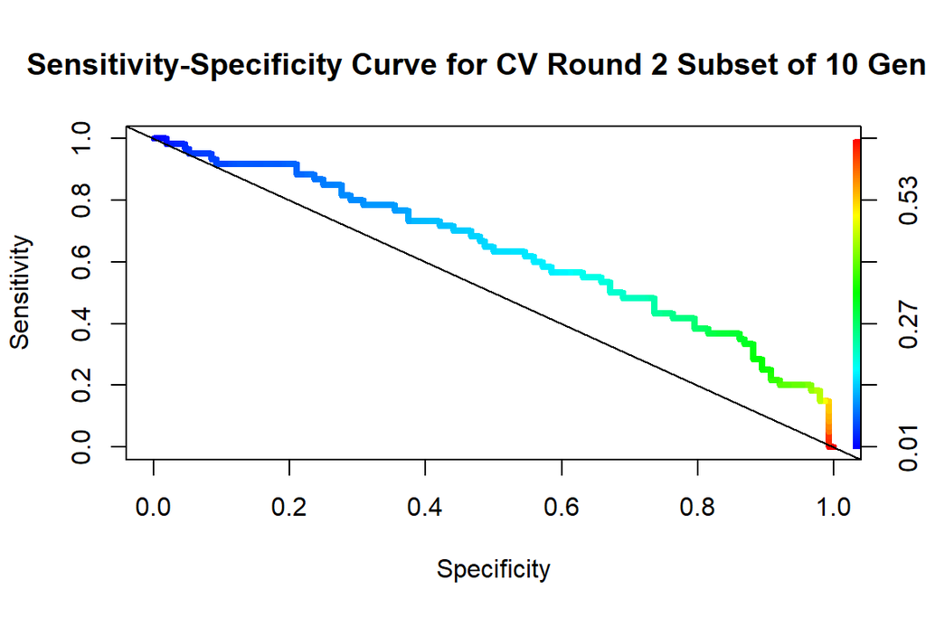

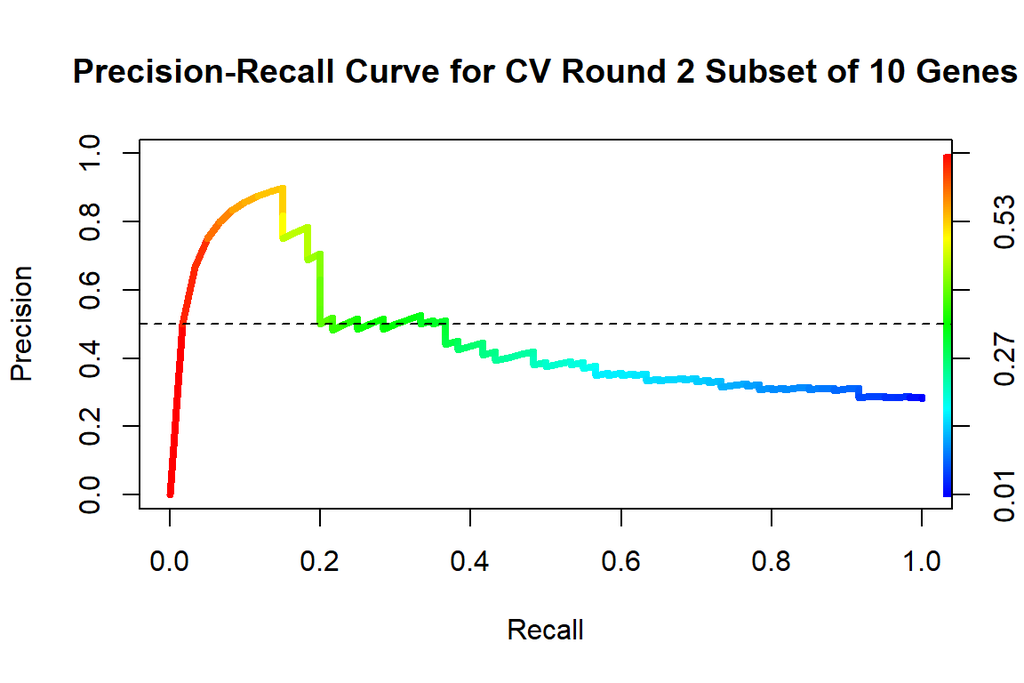

```
## Round 2 Cross Validation for using 10 differentially expressed genes
## Accuracy: 0.636792452830189
## Sensitivity-Specificity AUC: 0.672700729927007
## Smallest Sensitivity over .80: 0.802919708029197
## Corresponding Specifcity: 0.44
## Precision-Recall AUC: 0.672700729927007
## Maximum F-score: 0.570247933884298
## Maximum F-score Precision: 0.413173652694611
## Maximum F-score Recall: 0.92
```

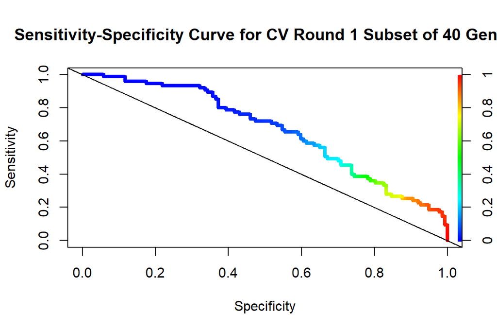

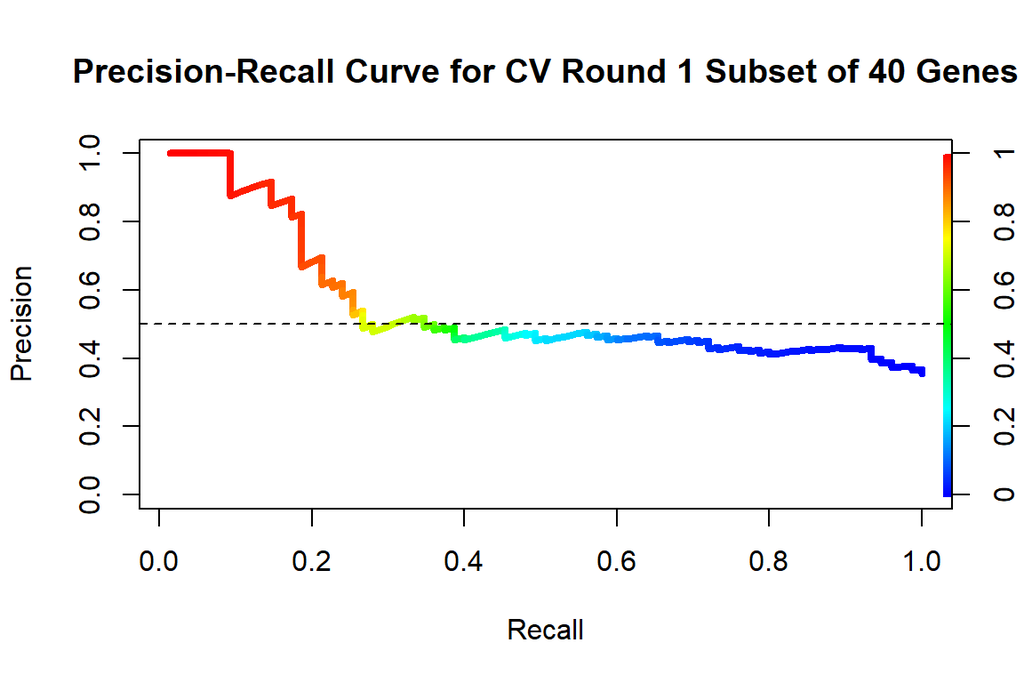

```
## Round 1 Cross Validation for using 40 differentially expressed genes
## Accuracy: 0.636792452830189
## Sensitivity-Specificity AUC: 0.664525547445255
## Smallest Sensitivity over .80: 0.802919708029197
## Corresponding Specifcity: 0.36
## Precision-Recall AUC: 0.664525547445255
## Maximum F-score: 0.588235294117647
## Maximum F-score Precision: 0.429447852760736
## Maximum F-score Recall: 0.933333333333333
```

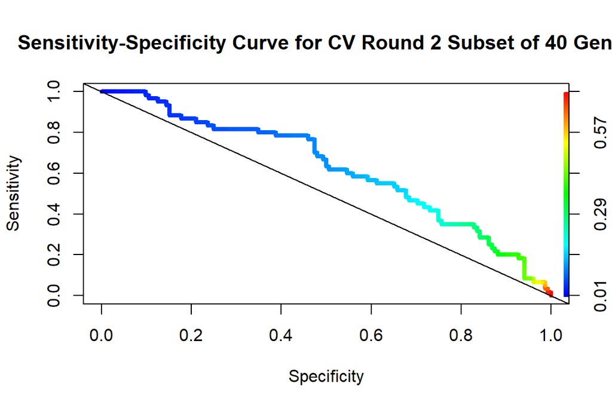

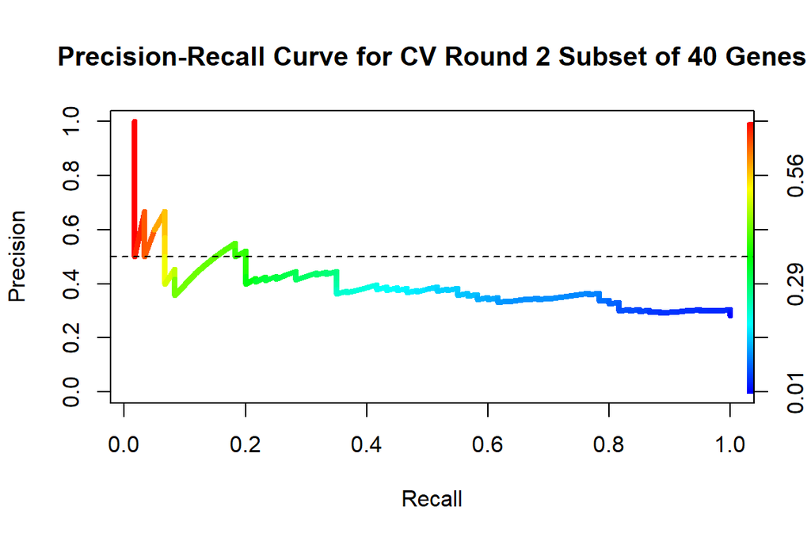

```
## Round 2 Cross Validation for using 40 differentially expressed genes
## Accuracy: 0.636792452830189
## Sensitivity-Specificity AUC: 0.664525547445255
## Smallest Sensitivity over .80: 0.802919708029197
## Corresponding Specifcity: 0.36
## Precision-Recall AUC: 0.664525547445255
## Maximum F-score: 0.588235294117647
## Maximum F-score Precision: 0.429447852760736
## Maximum F-score Recall: 0.933333333333333
```

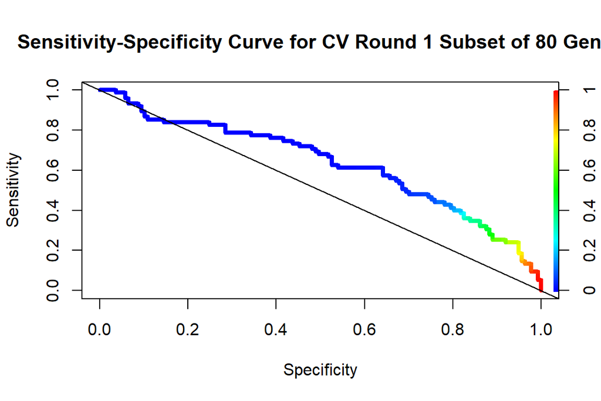

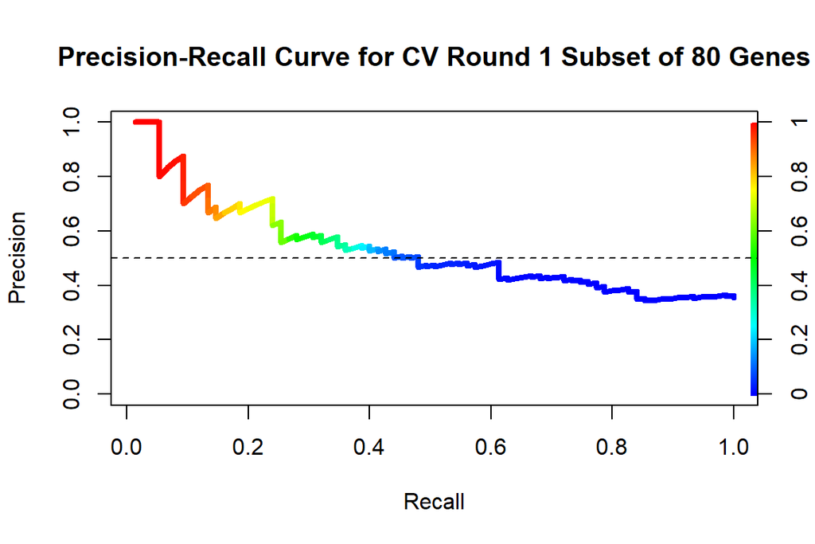

```
## Round 1 Cross Validation for using 80 differentially expressed genes
## Accuracy: 0.669811320754717
## Sensitivity-Specificity AUC: 0.633479318734793
## Smallest Sensitivity over .80: 0.802919708029197
## Corresponding Specifcity: 0.413333333333333
## Precision-Recall AUC: 0.633479318734793
## Maximum F-score: 0.541176470588235
## Maximum F-score Precision: 0.484210526315789
## Maximum F-score Recall: 0.613333333333333
```

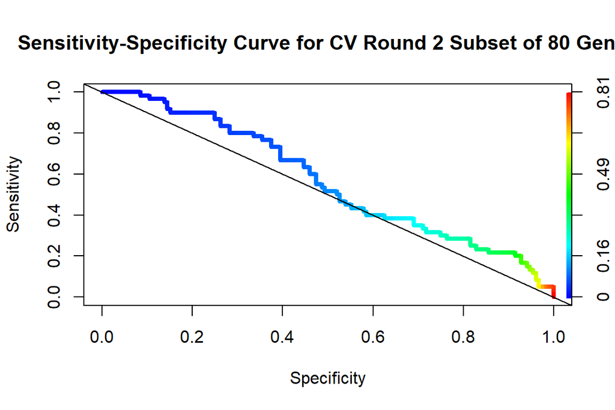

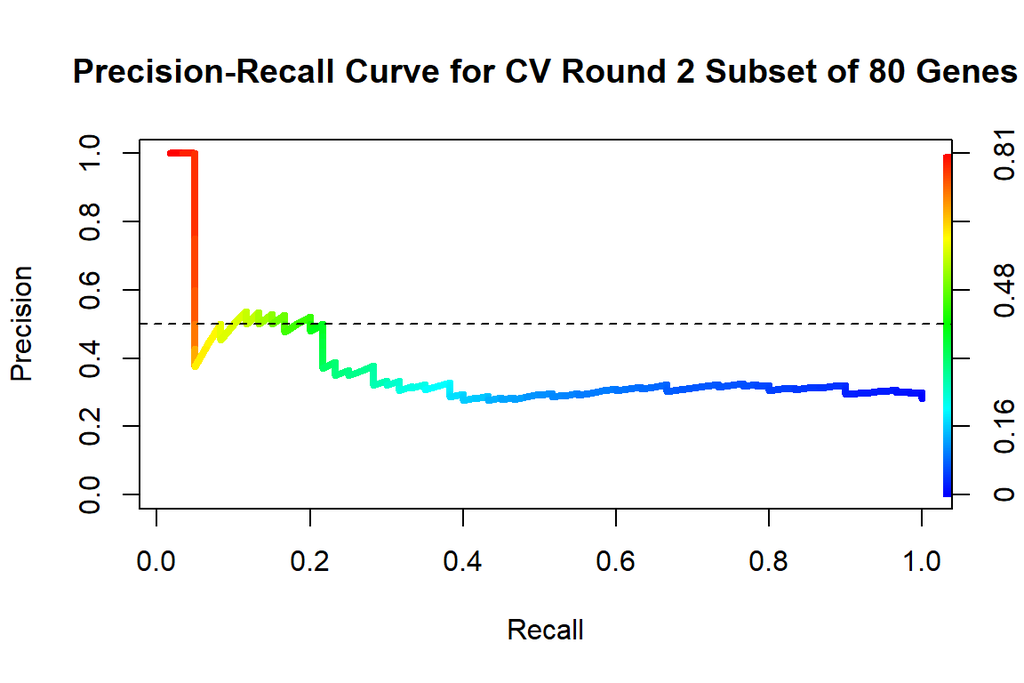

```
## Round 2 Cross Validation for using 80 differentially expressed genes
## Accuracy: 0.669811320754717
## Sensitivity-Specificity AUC: 0.633479318734793
## Smallest Sensitivity over .80: 0.802919708029197
## Corresponding Specifcity: 0.413333333333333
## Precision-Recall AUC: 0.633479318734793
## Maximum F-score: 0.541176470588235
## Maximum F-score Precision: 0.484210526315789
## Maximum F-score Recall: 0.613333333333333
```

[4 more figures not shown]

```
## Round 2 Cross Validation for using 100 differentially expressed genes
## Accuracy: 0.679245283018868
## Sensitivity-Specificity AUC: 0.653527980535279
## Smallest Sensitivity over .80: 0.802919708029197
## Corresponding Specifcity: 0.466666666666667
## Precision-Recall AUC: 0.653527980535279
## Maximum F-score: 0.568421052631579
## Maximum F-score Precision: 0.469565217391304
## Maximum F-score Recall: 0.72
```

```r
# Apply Suppor Vector Machine to filtered genes and train classifier



### create function here so you can test subsets of 10, 50, 100, and 1000
SVM_arrange <- function(x, topxIndices,train_Pheno, train_Expr, test_Pheno, test_Expr){
# Using x top differentially expressed genes
# Arrange Data for svm function (create combined matrices with class labels and expression data)
  nsamples <- length(train_Pheno)
  topxIndices <- topxIndices[1:x]

  train = data.frame(x = t(train_Expr[topxIndices,]), y = as.factor(train_Pheno))
  test = data.frame(x = t(test_Expr[topxIndices,]), y = as.factor(test_Pheno))
  colnames(train) <- c(1:x, 'train_Ph')
  colnames(test) <- c(1:x, 'test_Ph')
  return (list(tr = train,te = test))
}

accuracy <- function(svm_predictions,test_Pheno){
  nsamples = length(test_Pheno)
  pred <- (as.numeric(svm_predictions) == 2)
  svm_classifier.acc <- length(which(pred == test_Pheno))/nsamples
  return (list(acc = svm_classifier.acc))
}

# ROC sensitivity and specificity function which plots the sensitivity and specificity of the cancer predictions on a graph
roc_ss <- function(svm_predictions,test,r){
  x <- length(test[1,])-1
  prob.cancer <- attr (svm_predictions, "probabilities")[, 1]
  roc.pred <- prediction (prob.cancer, test$test_Ph == 1)
  perf <- performance (roc.pred, "sens", "spec")
  plot(perf,colorize = TRUE, main = paste("Sensitivity-Specificity Curve for CV Round",r, 'Subset of',x,'Genes'),lwd = 4, xlab = 'Specificity',ylab = 'Sensitivity',ylim=range(0:1))
  abline(a = 1, b = -1)

  # AUC for Sensitivity-Specificity Curve
  svm_classifier.ss_auc<-performance(roc.pred,"auc")@y.values[[1]]
  # Sensitivity value closest to and greater than .8
  svm_classifier.sens_80 <- perf@x.values[[1]][max(which(perf@x.values[[1]]>.8))]
  # Corresponding specificity
  svm_classifier.spec_80 <- perf@y.values[[1]][max(which(perf@x.values[[1]]>.8))]
  return (list(spec80 = svm_classifier.spec_80,sens80 = svm_classifier.sens_80,ssAuc = svm_classifier.ss_auc))
}

# ROC precision recall function which plots the precision and recall of the cancer predictions on a graph
roc_pr <- function(svm_predictions,test,r){
  x <- length(test[1,])-1
  prob.cancer <- attr (svm_predictions, "probabilities")[, 1]
  roc.pred <- prediction (prob.cancer, test$test_Ph == 1)

  perf <- performance (roc.pred, "prec", "rec")
  plot(perf,colorize = TRUE, main = paste("Precision-Recall Curve for CV Round",r,'Subset of',x,'Genes'),lwd = 4, xlab = 'Recall',ylab = 'Precision',ylim=range(0:1))
  abline(h = 0.5, lty = 2)
  svm_classifier.pr_auc <- performance(roc.pred,"auc")@y.values[[1]]
  f_scores<-performance(roc.pred,"f")@y.values[[1]] # maximum F-score
  svm_classifier.f <- f_scores[which.max(f_scores)]
  svm_classifier.prec_f <- perf@y.values[[1]][which.max(f_scores)] # precision for max F-score
  svm_classifier.rec_f <- perf@x.values[[1]][which.max(f_scores)] # recall for max F-score
  return (list(f = svm_classifier.f, precf = svm_classifier.prec_f,recf = svm_classifier.rec_f, prAuc = svm_classifier.pr_auc))

}

# The below function performs the svm classifier with a linear kernel, calculates accuracy, sensitivity & specificity, precision & recall
SVM_analysis <- function(x,topxIndices,train_Pheno,train_Expr,test_Pheno,test_Expr,r){
  arrange_svm <- SVM_arrange(x, topxIndices,train_Pheno, train_Expr, test_Pheno, test_Expr)
  train <- arrange_svm$tr
  test <- arrange_svm$te
# Perform Svm classification
# Find optimum Parameters
  #tune_classifier <- tune(svm,factor(train_Ph) ~.,data = train,kernel = 'linear',ranges = list(cost = c(.001,.01,.1,1,10,100)),probability = TRUE,scale = FALSE)
# It can be seen from the tune function that the optimum value for cost is .01
# Therefore, the calculations and generatoin of the ROC plot below will use this value
  test_Expr <- test[-x-1]
  svm_classifier <- svm(factor(train_Ph)~., train, kernel = 'linear',
                        cost = 1,probability = TRUE,scale = FALSE)

  svm_predictions <- predict(svm_classifier,test,decision.values = TRUE,probability = TRUE)
  svm_classifier.acc <- accuracy(svm_predictions,test_Pheno)



  # Now create ROC curve of sensitivity vs. specificity
  svm_ss <- roc_ss(svm_predictions,test,r)

  # Now for the Precision Recall Graph:
  svm_pr <- roc_pr(svm_predictions,test,r)


  return (list(f = svm_pr$f,precf = svm_pr$precf,recf = svm_pr$recf, ssAuc = svm_ss$ssAuc, sens80 = svm_ss$sens80, spec80 = svm_ss$spec80, acc = svm_classifier.acc,prAuc = svm_pr$prAuc))
}

subsets = c(10,40,80,100)
# Now to display the specific metrics for each subset size of the classifier
for (i in seq(1,length(subsets))){

  svm_classifier <- SVM_analysis(subsets[i],f1_topxIndices,f1_Pheno,f1_Expr,f2_Pheno,f2_Expr,1)
  cat(paste('Round 1 Cross Validation for using',subsets[i],'differentially expressed genes \n'))
  cat(paste('Accuracy:',svm_classifier$acc,'\n'))
  cat(paste('Sensitivity-Specificity AUC:', svm_classifier$ssAuc,'\n'))
  cat(paste('Smallest Sensitivity over .80:',svm_classifier$sens80,'\n'))
  cat(paste('Corresponding Specifcity:',svm_classifier$spec80,'\n'))
  cat(paste('Precision-Recall AUC:', svm_classifier$prAuc,'\n'))
  cat(paste('Maximum F-score:',svm_classifier$f,'\n'))
  cat(paste('Maximum F-score Precision:',svm_classifier$precf,'\n'))
  cat(paste('Maximum F-score Recall:',svm_classifier$recf,'\n'))
  cat('\n')

  SVM_analysis(subsets[i],f2_topxIndices,f2_Pheno,f2_Expr,f1_Pheno,f1_Expr,2)
  cat(paste('Round 2 Cross Validation for using',subsets[i],'differentially expressed genes \n'))
  cat(paste('Accuracy:',svm_classifier$acc,'\n'))
  cat(paste('Sensitivity-Specificity AUC:', svm_classifier$ssAuc,'\n'))
  cat(paste('Smallest Sensitivity over .80:',svm_classifier$sens80,'\n'))
  cat(paste('Corresponding Specifcity:',svm_classifier$spec80,'\n'))
  cat(paste('Precision-Recall AUC:', svm_classifier$prAuc,'\n'))
  cat(paste('Maximum F-score:',svm_classifier$f,'\n'))
  cat(paste('Maximum F-score Precision:',svm_classifier$precf,'\n'))
  cat(paste('Maximum F-score Recall:',svm_classifier$recf,'\n'))
  cat('\n')
  cat('\n')
}
```

[output not shown]

It can be seen that as the number of differentially expressed genes that are used increases, the measures of performance of the SVM classifier varies. The maximum f-score is almost completely consistent throughout being around .57, however the recall decreases as the number of genes that are included increases, and the precision somewhat increases. The specificity at 80% sensitivity is seen to be a maximum at using 100 differntially expressed genes (around .46). the maximum f-score is seen when using 40 differentially expressed genes at a score of about .588 for both rounds of cross validation. All of the scores have been printed above.

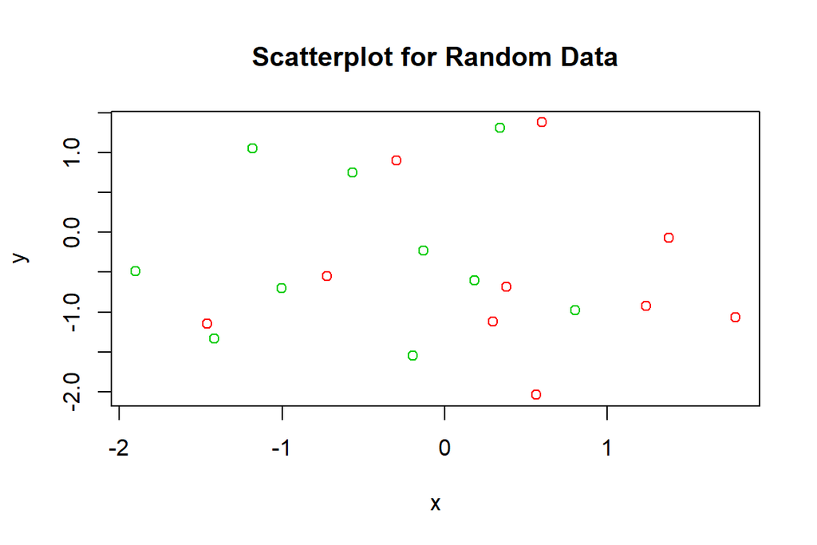

```r
roc_ss <- function(svm_predictions,test,r){
  x <- length(test[1,])-1
  prob.cancer <- attr (svm_predictions, "probabilities")[, 1]
  roc.pred <- prediction (prob.cancer, test$test_Ph == 0)
  perf <- performance (roc.pred, "sens", "spec")
  plot(perf, colorize = TRUE,main = paste("Sensitivity-Specificity Curve for CV Round",r, 'Subset of',x,'Genes'),lwd = 4, xlab = 'Specificity',ylab = 'Sensitivity',ylim=range(0:1))
  abline(a = 1, b = -1)

  # AUC for Sensitivity-Specificity Curve
  svm_classifier.ss_auc<-performance(roc.pred,"auc")@y.values[[1]]
  # Sensitivity value closest to and greater than .8
  svm_classifier.sens_80 <- perf@x.values[[1]][max(which(perf@x.values[[1]]>.8))]
  # Corresponding specificity
  svm_classifier.spec_80 <- perf@y.values[[1]][max(which(perf@x.values[[1]]>.8))]
  return (list(spec80 = svm_classifier.spec_80,sens80 = svm_classifier.sens_80,ssAuc = svm_classifier.ss_auc))
}

roc_pr <- function(svm_predictions,test,r){
  x <- length(test[1,])-1
  prob.cancer <- attr (svm_predictions, "probabilities")[, 1]
  roc.pred <- prediction (prob.cancer, test$test_Ph == 0)

  perf <- performance (roc.pred, "prec", "rec")
  plot(perf, colorize = TRUE,main = paste("Precision-Recall Curve for CV Round",r,'Subset of',x,'Genes'),lwd = 4, xlab = 'Recall',ylab = 'Precision',ylim=range(0:1))
  abline(h = 0.5, lty = 2)
  svm_classifier.pr_auc <- performance(roc.pred,"auc")@y.values[[1]]
  f_scores<-performance(roc.pred,"f")@y.values[[1]] # maximum F-score
  svm_classifier.f <- f_scores[which.max(f_scores)]
  svm_classifier.prec_f <- perf@y.values[[1]][which.max(f_scores)] # precision for max F-score
  svm_classifier.rec_f <- perf@x.values[[1]][which.max(f_scores)] # recall for max F-score
  return (list(f = svm_classifier.f, precf = svm_classifier.prec_f,recf = svm_classifier.rec_f, prAuc = svm_classifier.pr_auc))

}


# Random Classifier example
# Because the data is very complicated, I decided to test this on a random set that was
# impossible to classify, and on a data set that was very classifiable. I have shown the
# scatterplot below for both data sets, and for the first there exists no reasonable
# hyperplane of separability for SVM, while in the second we could choose a very obvious
# slanted line down the plot to separate the classes

# Here's a data set that is impossible to classify using a linear kernel:
x = matrix(rnorm(40),ncol = 2)
y = c(rep(0,10),rep(1,10))
x[y==1,]=x[y==1,]+2

toph <- c(1, 2)
testx_r = matrix(rnorm(40),ncol = 2)
testy_r = c(rep(0,10),rep(1,10))
testy_r <- sample(c(0,1),20,rep = TRUE)
plot(testx_r,col=(3-testy_r),main = "Scatterplot for Random Data",xlab='x',ylab= 'y')
```

```r
x = t(x)
y = t(y)

svm_classifier<- SVM_analysis(2,toph,y,x,testy_r,testx_r,1)
```

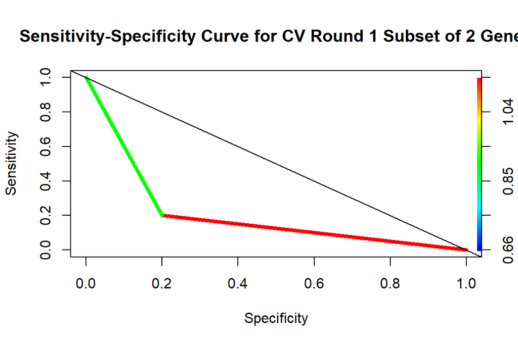

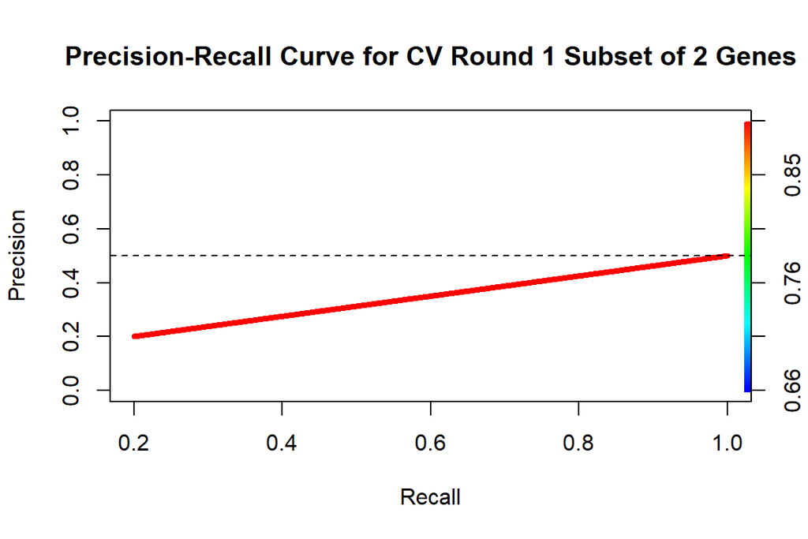

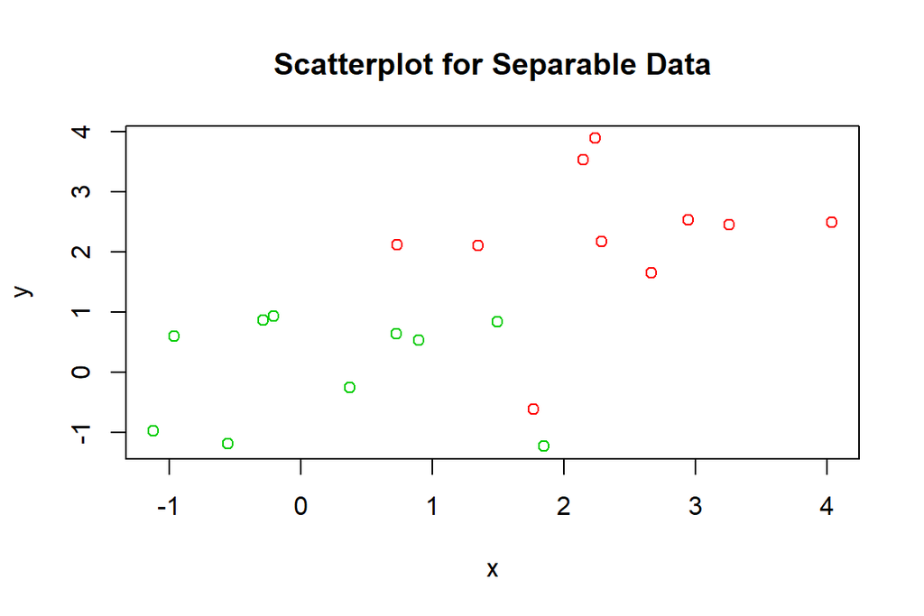

```r
# Now for separable data:
testx = matrix(rnorm(40),ncol =2)
testy = c(rep(0,10),rep(1,10))
testx[testy ==1,]= testx[testy ==1,]+3
plot(testx,col=(3-testy),main = "Scatterplot for Separable Data",xlab='x',ylab= 'y')
```

```r
# Transpose to be in same form as gene data
testx = t(testx)
testy = t(testy)


svm_classifier<- SVM_analysis(2,toph,y,x,testy,testx,2)
```

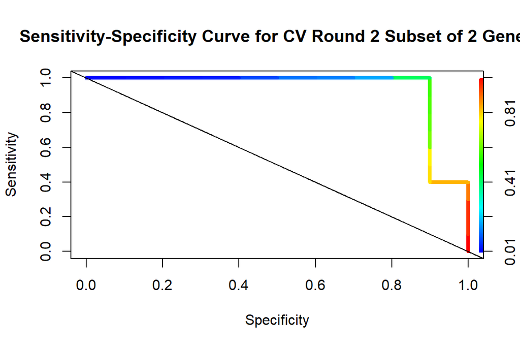

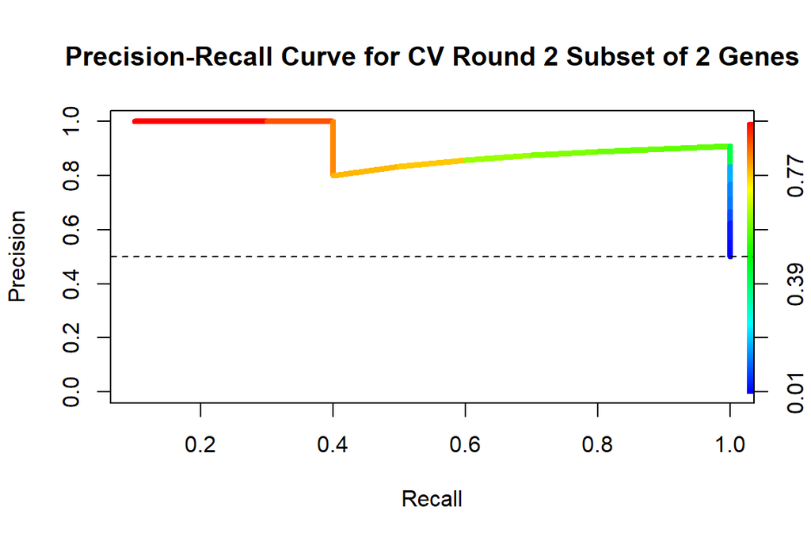